# Lab

# 1 Uppgift 1. Enkel linjär regression

## 1.1 (a) Simulera data och anpassa modellen

Vi genererar heltal $x=1,\dots,20$ och simulerar $y=\beta_0+\beta_1 x+\varepsilon$ med $\beta_0=2$, $\beta_1=1$, $\varepsilon\sim\mathcal{N}(0,\sigma^2)$, $\sigma=3$. Dessa värden ger $R^2$ mellan 70–90%.

```r
set.seed(123)                 # reproducerbart en gång
x <- 1:20
beta0 <- 2
beta1 <- 1
sigma <- 3
eps <- rnorm(length(x), mean = 0, sd = sigma)
y <- beta0 + beta1*x + eps

fit <- lm(y ~ x)
summary(fit)
```

```
##
## Call:
## lm(formula = y ~ x)
##
## Residuals:
##    Min     1Q Median     3Q    Max
## -5.964 -1.808 -0.113  1.558  5.201
##
## Coefficients:
##             Estimate Std. Error t value Pr(>|t|)
## (Intercept)   2.9303     1.3860   2.114   0.0487 *
## x             0.9519     0.1157   8.227 1.64e-07 ***
## ---
## Signif. codes:  0 '***' 0.001 '**' 0.01 '*' 0.05 '.' 0.1 ' ' 1
##
## Residual standard error: 2.984 on 18 degrees of freedom
## Multiple R-squared:  0.7899, Adjusted R-squared:  0.7783
## F-statistic: 67.68 on 1 and 18 DF,  p-value: 1.642e-07
```

## 1.2 (b) 95% konfidensintervall för $\beta_0,\beta_1$

```r
(ci <- confint(fit, level = 0.95))
```

```
##                  2.5 %   97.5 %
## (Intercept) 0.01840497 5.842150
## x           0.70878766 1.194945
```

Ja, de finns i intervallen.

## 1.3 (c) Grafisk diagnostik

Sexp figurer: spridningsdiagram (utan linje), spridningsdiagram med anpassad linje samt de 4 diagnostiska plottarna.

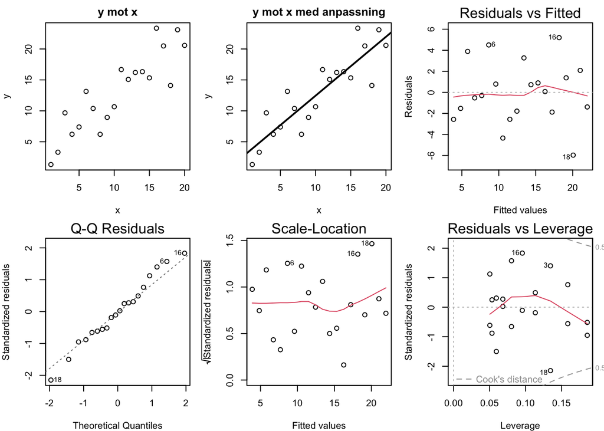

```r
op <- par(mfrow = c(2, 3), mar = c(4,4,2,1))
plot(x, y, main = "y mot x", xlab = "x", ylab = "y")
plot(x, y, main = "y mot x med anpassning", xlab = "x", ylab = "y")
abline(fit, lwd = 2)

plot(fit, which = 1)  # Residualer mot anpassade värden (Residuals vs Fitted)
plot(fit, which = 2)  # Normal Q-Q
plot(fit, which = 3)  # Scale-Location
plot(fit, which = 5)  # Residualer mot hävstång (Cook's konturer)
```

```r
par(op)
```

**Vad plottarna visar:**

- **Spridningsdiagrammen**: linjärt samband tydligt.
- **Residualer mot anpassade värden**: kontrollerar linearitet & konstant varians (bör vara slumpmoln).
- **Normal Q–Q**: kontrollerar ungefärlig normalitet (punkter nära linjen).
- **Scale–Location**: kontrollerar homogen varians (platt band).
- **Residualer mot hävstång (Cook’s distans)**: flaggar hög hävstång/inflytande.

Modellen passar väl till datan.

## 1.4 (d) Upprepade simuleringar för att se diagnostikens variation

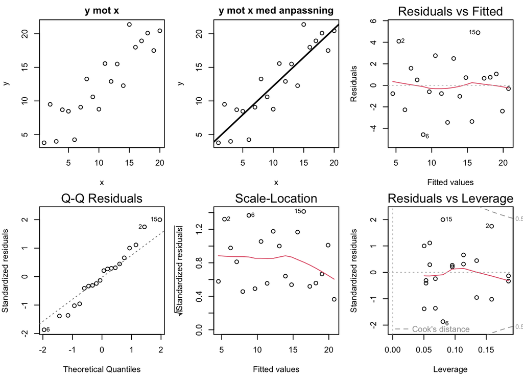

```r
seed <- sample(1:100, 1)
set.seed(seed)
# Simulera en ny datamängd vid varje körning och rita om diagnostiken
x <- 1:20
beta0 <- 2; beta1 <- 1; sigma <- 3
y <- beta0 + beta1*x + rnorm(length(x), 0, sigma)
fit <- lm(y ~ x)

op <- par(mfrow = c(2, 3), mar = c(4,4,2,1))
plot(x, y, main = "y mot x", xlab = "x", ylab = "y")
plot(x, y, main = "y mot x med anpassning", xlab = "x", ylab = "y"); abline(fit, lwd = 2)
plot(fit, which = 1); plot(fit, which = 2); plot(fit, which = 3); plot(fit, which = 5)
```

```r
par(op)

set.seed(123)
```

Även när modellen stämmer kan residualmönster, QQ-svansar och Scale–Location-kurvan variera på grund av slump; plott av hävstång/Cook’s är oftast mest stabil såvida inte ett extremt drag uppstår. Små mönster ska tolkas med försiktighet.

## 1.5 (e) Bryt mot antagandet om homogen varians (variansen ökar med $x$)

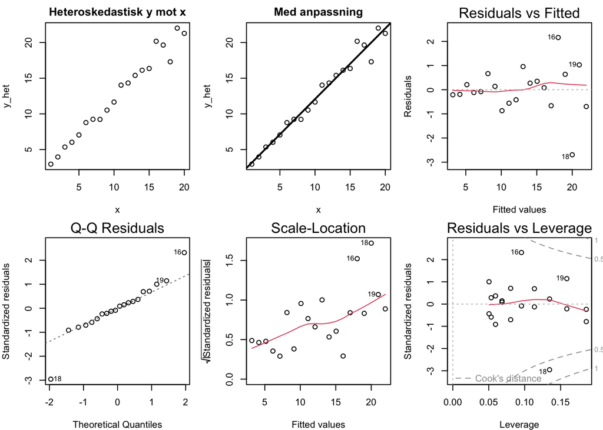

```r
set.seed(123)
x <- 1:20
beta0 <- 2; beta1 <- 1; sigma <- 0.8
y_het <- beta0 + beta1*x + rnorm(length(x), 0, sigma * (x/mean(x)))
fit_het <- lm(y_het ~ x)

op <- par(mfrow = c(2, 3), mar = c(4,4,2,1))
plot(x, y_het, main = "Heteroskedastisk y mot x")
plot(x, y_het, main = "Med anpassning"); abline(fit_het, lwd = 2)
plot(fit_het, which = 1); plot(fit_het, which = 2); plot(fit_het, which = 3); plot(fit_het, which = 5)
```

```r
par(op)
```

**Tolkning (e):**

## 1.6 (f) Bryt mot linearitetsantagandet (sann kvadratisk term)

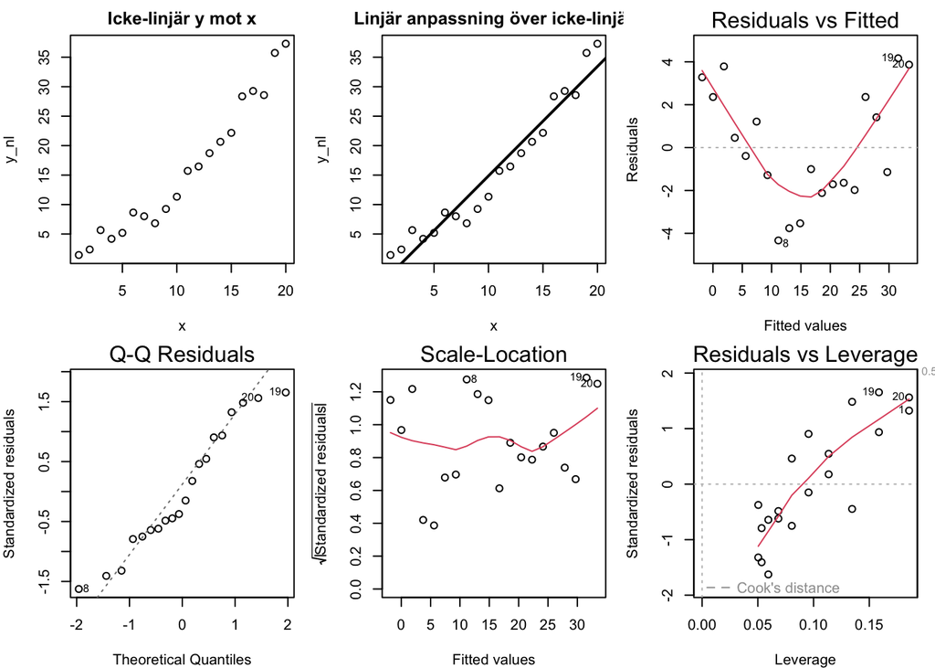

```r
set.seed(123)
x <- 1:20
beta0 <- 2; beta1 <- 0.2; beta2 <- 0.08; sigma <- 1.5
y_nl <- beta0 + beta1*x + beta2*x^2 + rnorm(length(x), 0, sigma)
fit_lin <- lm(y_nl ~ x)      # (fel)anpassa en linjär modell

op <- par(mfrow = c(2, 3), mar = c(4,4,2,1))
plot(x, y_nl, main = "Icke-linjär y mot x")
plot(x, y_nl, main = "Linjär anpassning över icke-linjär"); abline(fit_lin, lwd = 2)
plot(fit_lin, which = 1); plot(fit_lin, which = 2); plot(fit_lin, which = 3); plot(fit_lin, which = 5)
```

```r
par(op)
```

**Tolkning (f):**

- Spridningsdiagrammen visar tydlig **krökning (kvadratisk trend)** – en linjär modell är fel
- **Residuals vs Fitted:** markerad U-form ⇒ stark **icke-linearitet**.
- **Scale–Location:** ingen tydlig trattform ⇒ variansen verkar ungefär konstant.
- **Q–Q:** nära linjen ⇒ residualerna är ungefär **normala**.
- **Residuals vs Leverage:** ytterpunkter har hög **hävstång**, viss men inte extrem påverkan (Cook’s inte passerad).

## 1.7 (g) Avvikare: inflytelserik vs icke-inflytelserik

Utgå från en ren linjär modell och stör en observation på två sätt.

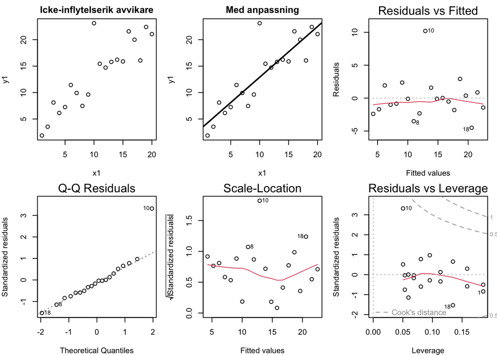

```r
set.seed(123)
x <- 1:20
beta0 <- 2; beta1 <- 1; sigma <- 2
y_base <- beta0 + beta1*x + rnorm(length(x), 0, sigma)

## Fall 1: Icke-inflytelserik y-avvikare vid genomsnittlig hävstång
x1 <- x
y1 <- y_base
y1[10] <- y1[10] + 12     # stort residual vid måttligt x
fit1 <- lm(y1 ~ x1)

## Fall 2: Inflytelserik hög-hävstångs-avvikare (extremt x)
x2 <- x
x2[20] <- 40              # långt utanför designintervallet
y2 <- y_base
y2[20] <- beta0 + beta1*x2[20] + rnorm(1, 0, 6) + 10  # även förskjuten i y
fit2 <- lm(y2 ~ x2)

# Plottar: vardera i ett 2x3-upplägg
op <- par(mfrow = c(2, 3), mar = c(4,4,2,1))
plot(x1, y1, main = "Icke-inflytelserik avvikare")
plot(x1, y1, main = "Med anpassning"); abline(fit1, lwd = 2)
plot(fit1, which = 1); plot(fit1, which = 2); plot(fit1, which = 3); plot(fit1, which = 5)
```

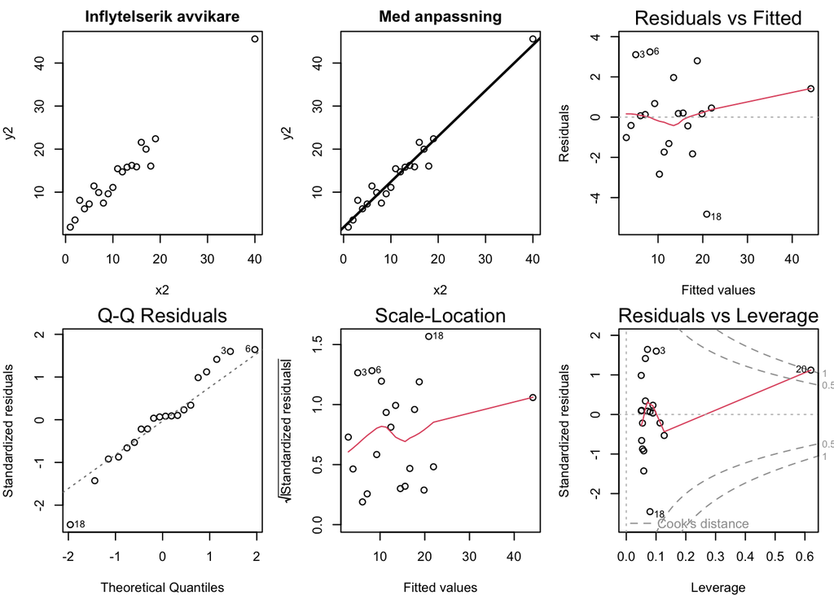

```r
par(op)

op <- par(mfrow = c(2, 3), mar = c(4,4,2,1))
plot(x2, y2, main = "Inflytelserik avvikare")
plot(x2, y2, main = "Med anpassning"); abline(fit2, lwd = 2)
plot(fit2, which = 1); plot(fit2, which = 2); plot(fit2, which = 3); plot(fit2, which = 5)
```

```r
par(op)
```

**Tolkning (g):**

- **Icke-inflytelserik outlier (fall 1):** I spridningsdiagrammet syns en tydlig y-avvikare kring medel-x. Den ger **stort residual** (Residuals vs Fitted) och avviker i **Q–Q** men har **låg hävstång**; i **Residuals vs Leverage** ligger punkten långt till vänster och **under Cook’s**-konturer ⇒ liten påverkan på linjen.
- **Inflytelserik outlier (fall 2):** Punkt med **extremt x** drar regressionslinjen (synligt i “Med anpassning”). I **Residuals vs Leverage** har den **hög hävstång** och ligger nära/över **Cook’s**-konturer ⇒ **inflytelserik**. Residualen är inte nödvändigtvis störst i “Residuals vs Fitted”, men kombinationen av stort leverage + Cook’s gör den tydligt påverkande.

# 2 Uppgift 2. Multipel linjär regression — Cigarettdata

## 2.1 (a) Enkla regressioner för prediktion av CO

```r
# Läs in data -------------------------------------------------------------
cig <- read.csv("cigarette.csv", stringsAsFactors = FALSE)

# Snabb översikt
str(cig)
```

```
## 'data.frame':    25 obs. of  5 variables:
##  $ brand : chr  "Alpine" "Benson&Hedges" "BullDurham" "CamelLights" ...
##  $ tar   : num  14.1 16 29.8 8 4.1 15 8.8 12.4 16.6 14.9 ...
##  $ nico  : num  0.86 1.06 2.03 0.67 0.4 1.04 0.76 0.95 1.12 1.02 ...
##  $ weight: num  0.985 1.094 1.165 0.928 0.946 ...
##  $ CO    : num  13.6 16.6 23.5 10.2 5.4 15 9 12.3 16.3 15.4 ...
```

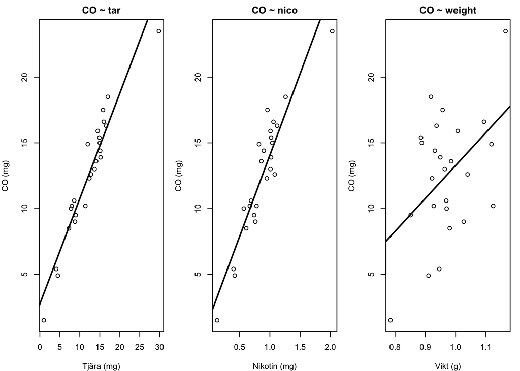

```r
# Spridningsdiagram med enkla linjära anpassningar
op <- par(mfrow = c(1, 3), mar = c(4,4,2,1))
plot(cig$tar, cig$CO, xlab = "Tjära (mg)", ylab = "CO (mg)", main = "CO ~ tar")
abline(lm(CO ~ tar, data = cig), lwd = 2)
plot(cig$nico, cig$CO, xlab = "Nikotin (mg)", ylab = "CO (mg)", main = "CO ~ nico")
abline(lm(CO ~ nico, data = cig), lwd = 2)
plot(cig$weight, cig$CO, xlab = "Vikt (g)", ylab = "CO (mg)", main = "CO ~ weight")
abline(lm(CO ~ weight, data = cig), lwd = 2)
```

```r
par(op)

# Anpassa enkla modeller och summera
m_tar    <- lm(CO ~ tar,    data = cig)
m_nico   <- lm(CO ~ nico,   data = cig)
m_weight <- lm(CO ~ weight, data = cig)

summary(m_tar)
```

```
##
## Call:
## lm(formula = CO ~ tar, data = cig)
##
## Residuals:
##     Min      1Q  Median      3Q     Max
## -3.1124 -0.7167 -0.3754  1.0091  2.5450
##
## Coefficients:
##             Estimate Std. Error t value Pr(>|t|)
## (Intercept)  2.74328    0.67521   4.063 0.000481 ***
## tar          0.80098    0.05032  15.918 6.55e-14 ***
## ---
## Signif. codes:  0 '***' 0.001 '**' 0.01 '*' 0.05 '.' 0.1 ' ' 1
##
## Residual standard error: 1.397 on 23 degrees of freedom
## Multiple R-squared:  0.9168, Adjusted R-squared:  0.9132
## F-statistic: 253.4 on 1 and 23 DF,  p-value: 6.552e-14
```

```r
summary(m_nico)
```

```
##
## Call:
## lm(formula = CO ~ nico, data = cig)
##
## Residuals:
##     Min      1Q  Median      3Q     Max
## -3.3273 -1.2228  0.2304  1.2700  3.9357
##
## Coefficients:
##             Estimate Std. Error t value Pr(>|t|)
## (Intercept)   1.6647     0.9936   1.675    0.107
## nico         12.3954     1.0542  11.759 3.31e-11 ***
## ---
## Signif. codes:  0 '***' 0.001 '**' 0.01 '*' 0.05 '.' 0.1 ' ' 1
##
## Residual standard error: 1.828 on 23 degrees of freedom
## Multiple R-squared:  0.8574, Adjusted R-squared:  0.8512
## F-statistic: 138.3 on 1 and 23 DF,  p-value: 3.312e-11
```

```r
summary(m_weight)
```

```
##
## Call:
## lm(formula = CO ~ weight, data = cig)
##
## Residuals:
##    Min     1Q Median     3Q    Max
## -6.524 -2.533  0.622  2.842  7.268
##
## Coefficients:
##             Estimate Std. Error t value Pr(>|t|)
## (Intercept)  -11.795      9.722  -1.213   0.2373
## weight        25.068      9.980   2.512   0.0195 *
## ---
## Signif. codes:  0 '***' 0.001 '**' 0.01 '*' 0.05 '.' 0.1 ' ' 1
##
## Residual standard error: 4.289 on 23 degrees of freedom
## Multiple R-squared:  0.2153, Adjusted R-squared:  0.1811
## F-statistic: 6.309 on 1 and 23 DF,  p-value: 0.01948
```

**Tolkning 2(a):**

Enkel linjär regression fungerar **väl** för att prediktera CO med **tjära** eller **nikotin** var för sig, men **dåligt** med **vikt** som ensam förklarande variabel.

## 2.2 (b) Multipel regression med alla tre prediktorer

```r
m_all <- lm(CO ~ tar + nico + weight, data = cig)
summary(m_all)
```

```
##
## Call:
## lm(formula = CO ~ tar + nico + weight, data = cig)
##
## Residuals:
##      Min       1Q   Median       3Q      Max
## -2.89261 -0.78269  0.00428  0.92891  2.45082
##
## Coefficients:
##             Estimate Std. Error t value Pr(>|t|)
## (Intercept)   3.2022     3.4618   0.925 0.365464
## tar           0.9626     0.2422   3.974 0.000692 ***
## nico         -2.6317     3.9006  -0.675 0.507234
## weight       -0.1305     3.8853  -0.034 0.973527
## ---
## Signif. codes:  0 '***' 0.001 '**' 0.01 '*' 0.05 '.' 0.1 ' ' 1
##
## Residual standard error: 1.446 on 21 degrees of freedom
## Multiple R-squared:  0.9186, Adjusted R-squared:  0.907
## F-statistic: 78.98 on 3 and 21 DF,  p-value: 1.329e-11
```

**Tolkning 2(b):**

- I den multipla modellen är **tjära** positiv och **signifikant** (β≈0.96, p≈7e-4).
- **Nikotin** blir **icke-signifikant** och byter tecken (β≈−2.6, p≈0.51) – typiskt tecken på **kollinearitet** med tjära.
- **Vikt** är också **icke-signifikant** (p≈0.97).
- $R^2=0.919$ är bara marginellt högre än för CO~tar, men **justerat $R^2=0.907$ är lägre** än för CO~tar (≈0.913), och residual-SE är större (1.45 vs 1.40).

Att lägga till nikotin och vikt ger ingen praktisk förbättring; **CO~tar** räcker bäst av de provade modellerna.

## 2.3 (c) Parvisa plottar för att förklara (b)

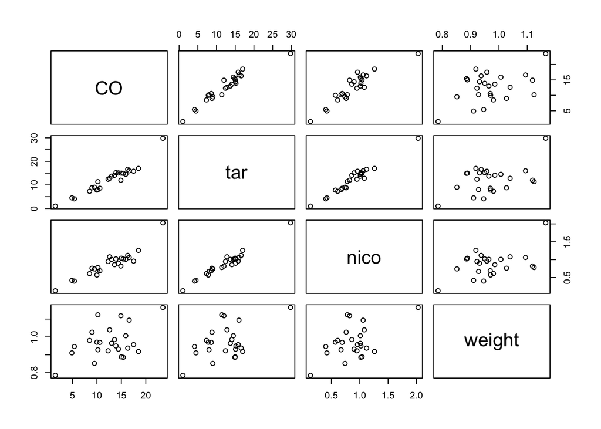

```r
pairs(~ CO + tar + nico + weight, data = cig)
```

**Tolkning 2(c):**

- **CO–tar** och **CO–nico**: tydliga, starkt positiva linjära samband → båda förklarar CO bra var för sig.
- **CO–weight**: svagt samband och stor spridning → dålig ensam prediktor.
- **tar–nico**: mycket starkt positiv korrelation → **kollinearitet**. Det förklarar att nikotin blir icke-signifikant och kan byta tecken i den multipla modellen i (b) när tjära redan finns med.
- **weight** mot tar/nico: inga starka samband → liten extra information att tillföra modellen.

## 2.4 (d) Residualdiagnostik för den multipla regressionen

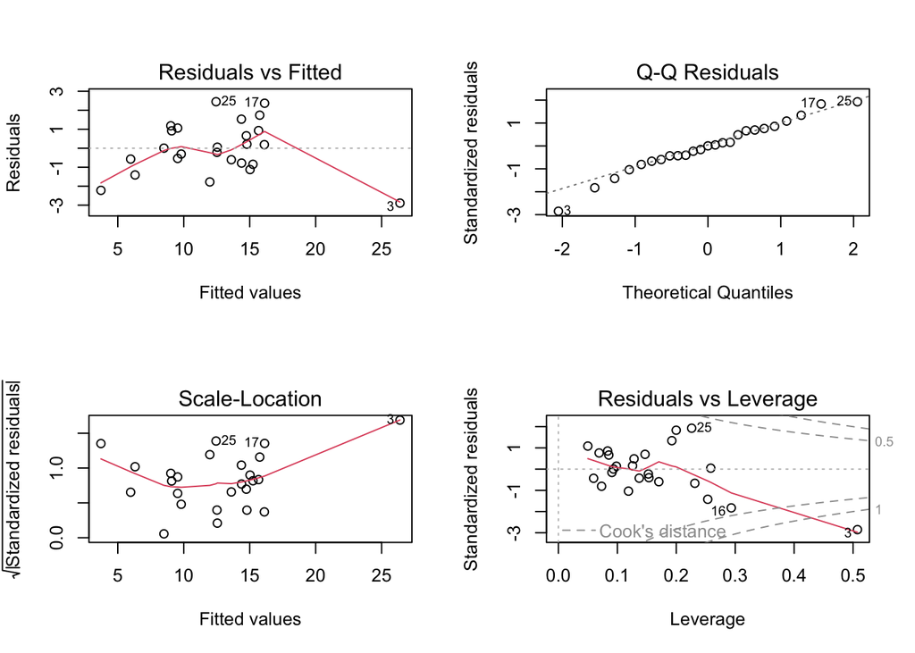

```r
op <- par(mfrow = c(2, 2))
plot(m_all)
```

```r
par(op)
```

## 2.5 (e) Identifiera och uteslut den tvivelaktiga observationen, anpassa om

```r
# Influensdiagnostik
infl <- influence.measures(m_all)
cook <- cooks.distance(m_all)
lev  <- hatvalues(m_all)

n <- nrow(cig)
thr <- 4/n                            # ett vanligt riktmärke för att flagga Cook's D
flag <- which(cook > thr)
data.frame(brand = cig$brand[flag], cooksD = cook[flag], leverage = lev[flag])
```

```
##            brand    cooksD  leverage
## 3     BullDurham 2.0937714 0.5074842
## 14   MultiFilter 0.1715736 0.2534280
## 16           Now 0.3463355 0.2933370
## 17       OldGold 0.2096934 0.1998589
## 25 WinstonLights 0.2712300 0.2261056
```

```r
# Ta bort den mest tvivelaktiga och anpassa om
idx_q <- flag[which.max(cook[flag])]
cig_red <- cig[-idx_q, ]

m_all_red <- lm(CO ~ tar + nico + weight, data = cig_red)
summary(m_all_red)
```

```
##
## Call:
## lm(formula = CO ~ tar + nico + weight, data = cig_red)
##
## Residuals:
##     Min      1Q  Median      3Q     Max
## -2.1083 -0.8046 -0.1199  1.0095  2.0501
##
## Coefficients:
##             Estimate Std. Error t value Pr(>|t|)
## (Intercept)  -0.5517     2.9713  -0.186 0.854569
## tar           0.8876     0.1955   4.540 0.000199 ***
## nico          0.5185     3.2523   0.159 0.874941
## weight        2.0793     3.1784   0.654 0.520431
## ---
## Signif. codes:  0 '***' 0.001 '**' 0.01 '*' 0.05 '.' 0.1 ' ' 1
##
## Residual standard error: 1.16 on 20 degrees of freedom
## Multiple R-squared:  0.935,  Adjusted R-squared:  0.9252
## F-statistic: 95.86 on 3 and 20 DF,  p-value: 4.85e-12
```

```r
# Jämför koefficienter, p-värden, R^2
coef_comparison <- cbind(
  full = coef(summary(m_all))[, c("Estimate", "Pr(>|t|)")],
  reduced = coef(summary(m_all_red))[, c("Estimate", "Pr(>|t|)")]
)
coef_comparison
```

```
##               Estimate     Pr(>|t|)   Estimate     Pr(>|t|)
## (Intercept)  3.2021900 0.3654642718 -0.5516976 0.8545685010
## tar          0.9625739 0.0006920652  0.8875803 0.0001990908
## nico        -2.6316611 0.5072342597  0.5184696 0.8749410220
## weight      -0.1304819 0.9735267532  2.0793442 0.5204306639
```

```r
c(R2_full = summary(m_all)$r.squared,
  AdjR2_full = summary(m_all)$adj.r.squared,
  R2_reduced = summary(m_all_red)$r.squared,
  AdjR2_reduced = summary(m_all_red)$adj.r.squared)
```

```
##       R2_full    AdjR2_full    R2_reduced AdjR2_reduced
##     0.9185893     0.9069593     0.9349753     0.9252216
```

**Tolkning 2(e):**

- **Tvivelaktig observation:** *BullDurham* (nr 3) – hög Cook’s D (~2.09) och hög hävstång (~0.51) ⇒ starkt inflytelserik.
- **Efter att ta bort den:**
  - Endast **tjära** är fortsatt **signifikant** (β≈0.89, p≈2e-4).
  - **Nikotin** blir positiv men **icke-signifikant**; **vikt** fortsatt icke-signifikant.
  - Modellens passform **förbättras**: $R^2$ från 0.919 → **0.935**, justerat $R^2$ från 0.907 → **0.925**, och residual-SE minskar (≈1.45 → **1.16**).

**Hur presentera:** Redovisa resultaten **med och utan** outlier. Slutsatsen är robust: CO förklaras främst av **tjära**; outlieren påverkade koefficienterna (framför allt tecknet för nikotin) och försämrade passformen.

## 2.6 (f) Modellval för prediktion (justerat $R^2$ och LOOCV-RMSEP)

Vi jämför kandidater med justerat $R^2$ och LOOCV-RMSEP. Vi överväger:

- tar; nico; weight (enskilda prediktorer)
- tar+nico; tar+weight; nico+weight
- tar+nico+weight (full)

Du kan beräkna med eller utan den tvivelaktiga observationen; motivera ditt val. Nedan visar vi båda och väljer modellen med **lägst RMSEP** (vid lika RMSEP bryter vi med högre justerat $R^2$ och parsimoni).

```r
# Hjälpare: LOOCV-RMSEP för en linjär modell specificerad med formel och data.frame
loocv_rmsep <- function(formula, data) {
  n <- nrow(data)
  # analytisk LOOCV med hatt-matris (gäller linjär minsta-kvadrat)
  X <- model.matrix(formula, data = data)
  y <- model.response(model.frame(formula, data = data))
  hat <- X %*% solve(t(X) %*% X) %*% t(X)
  fit <- X %*% solve(t(X) %*% X, t(X) %*% y)
  e <- y - fit
  loo_resid <- e / (1 - diag(hat))
  sqrt(mean(loo_resid^2))
}

cands <- list(
  `tar`                = CO ~ tar,
  `nico`               = CO ~ nico,
  `weight`             = CO ~ weight,
  `tar+nico`           = CO ~ tar + nico,
  `tar+weight`         = CO ~ tar + weight,
  `nico+weight`        = CO ~ nico + weight,
  `tar+nico+weight`    = CO ~ tar + nico + weight
)

eval_models <- function(dat) {
  do.call(rbind, lapply(names(cands), function(nm) {
    fm <- cands[[nm]]
    fit <- lm(fm, data = dat)
    data.frame(
      model = nm,
      adj_R2 = summary(fit)$adj.r.squared,
      RMSEP_LOOCV = loocv_rmsep(fm, dat),
      df = length(coef(fit))
    )
  }))
}

tab_full   <- eval_models(cig)
tab_reduced<- eval_models(cig_red)  # utan den flaggade observationen identifierad i (e)

tab_full[order(tab_full$RMSEP_LOOCV), ]
```

```
##             model    adj_R2 RMSEP_LOOCV df
## 1             tar 0.9131598    1.703965  2
## 4        tar+nico 0.9111836    1.767653  3
## 5      tar+weight 0.9092633    1.820918  3
## 7 tar+nico+weight 0.9069593    1.891851  4
## 2            nico 0.8511775    2.158176  2
## 6     nico+weight 0.8444138    2.273199  3
## 3          weight 0.1811389    4.612821  2
```

```r
tab_reduced[order(tab_reduced$RMSEP_LOOCV), ]
```

```
##             model    adj_R2 RMSEP_LOOCV df
## 1             tar 0.9304375    1.155383  2
## 4        tar+nico 0.9272585    1.212252  3
## 5      tar+weight 0.9286920    1.243623  3
## 7 tar+nico+weight 0.9252216    1.312462  4
## 2            nico 0.8597440    1.619577  2
## 6     nico+weight 0.8553717    1.701064  3
## 3          weight 0.0551404    4.435733  2
```

**Tolkning 2(f) – modellval:**

- **Bästa prediktor:** *Tjära*. Den ger lägst LOOCV-RMSEP och högst/lika högt justerat $R^2$ både med och utan den tvivelaktiga observationen.
- **Övriga:** *Nikotin* förklarar CO väl ensam men tillför nästan inget utöver tjära (kollinearitet). *Vikt* är svag.
- **Rekommenderad modell för prediktion:** **CO ~ tar** (enkel modell). Utan outlieren förbättras RMSEP ytterligare (≈1.16 vs ≈1.70) och adj.$R^2$ ökar (≈0.93). Modellen är bäst, enklast och mest stabil.